# The complex inner life of simple regression

github: mbrudd/simple

## Regression and data science

- Basic goal: *genuine insight* that *people* can understand
- Regression models are supposedly easy to build and to interpret…
- but experience suggests otherwise!
- To master regression, you have to understand the underlying mathematics and philosophy.
- Even simple regression is not so simple!

## Pearson-Lee height data

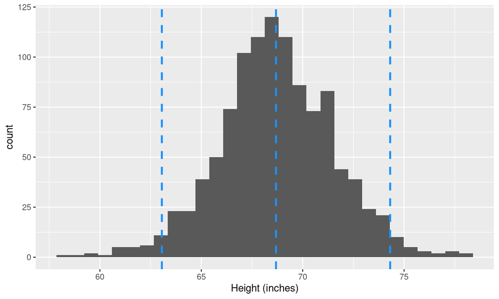

- 1,078 men; data collected in 1890s

## Pearson-Lee height data

These heights are roughly \(~ N(68.68, 2.81)\), so…

- our best guess of a height is the average, 68.68 inches,
- which will likely be wrong,
- but probably not by more than 2 SDs, 5.63 inches.
- This is a *null model*. More informed guesses should be better…

## Pearson-Lee height data

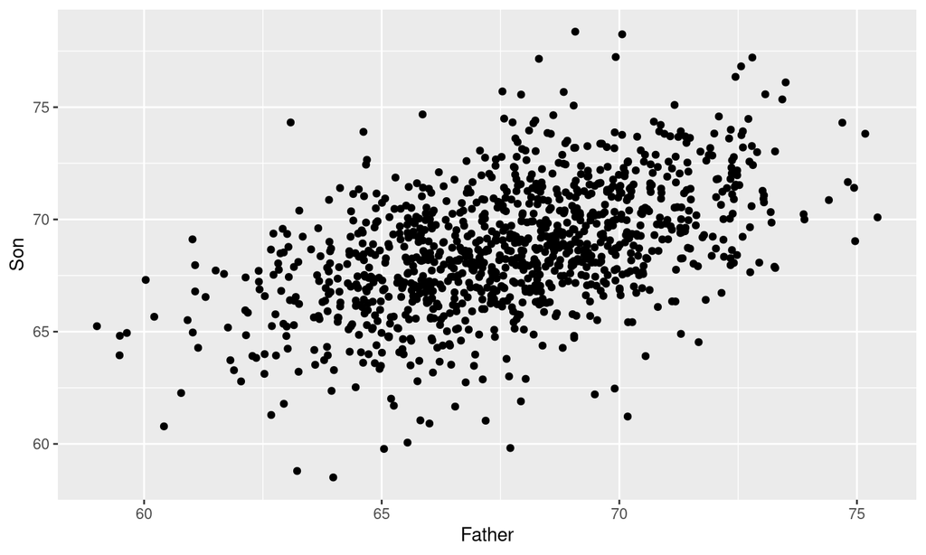

- Correlation: 0.5013

## Pearson-Lee height data

| Father’s rounded height | Number of sons | Average height | SD |
| --- | --- | --- | --- |
| 64 | 60 | 66.70 | 2.31 |
| 65 | 101 | 67.22 | 2.53 |
| 66 | 139 | 67.66 | 2.35 |
| 67 | 134 | 68.14 | 2.24 |
| 68 | 157 | 69.09 | 2.76 |
| 69 | 142 | 69.44 | 2.30 |
| 70 | 115 | 69.77 | 2.49 |
| 71 | 77 | 70.54 | 2.31 |
| 72 | 50 | 70.68 | 2.33 |

## Pearson-Lee height data

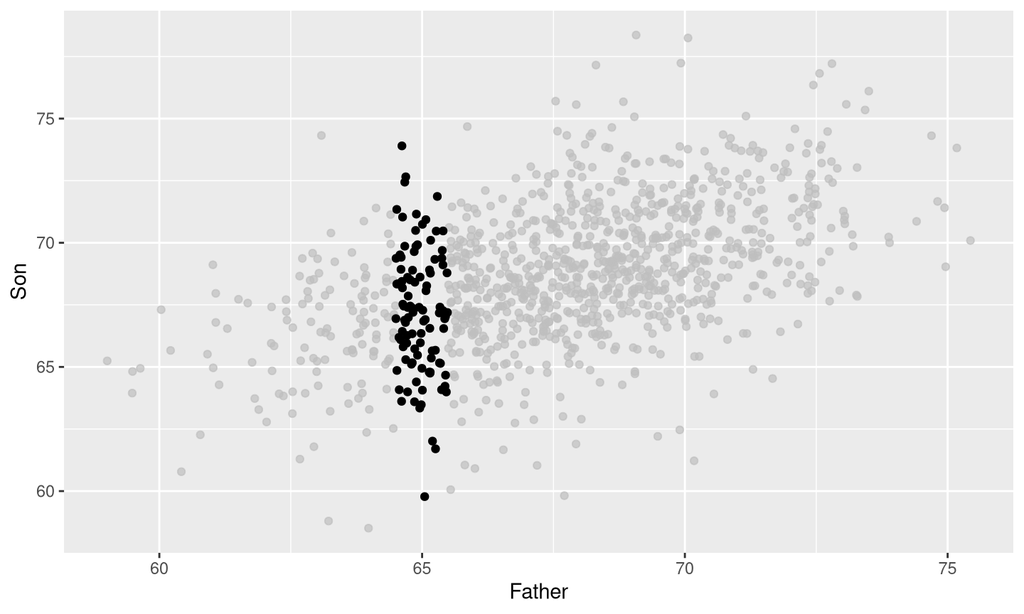

- Sons of 65" tall fathers

## Pearson-Lee height data

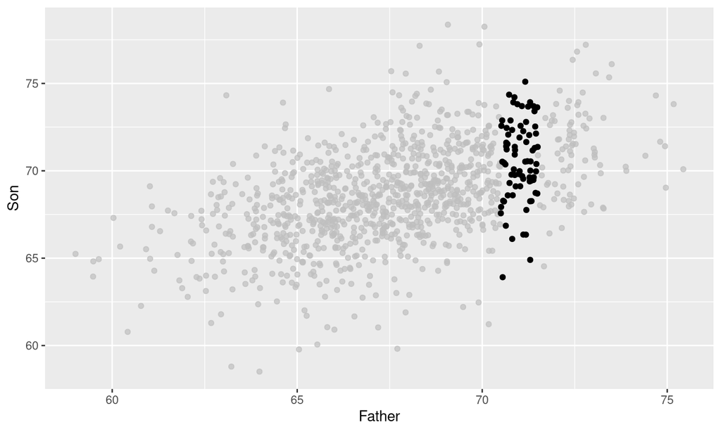

- Sons of 71" tall fathers

## Pearson-Lee height data

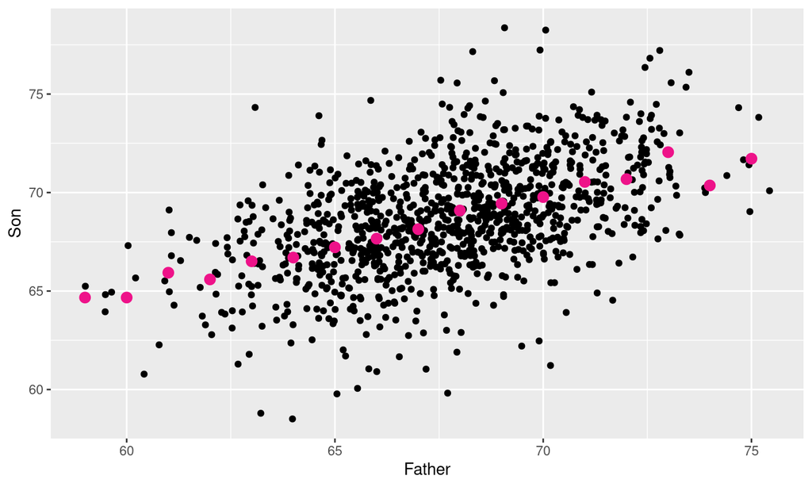

- Average heights for groups

## Pearson-Lee height data

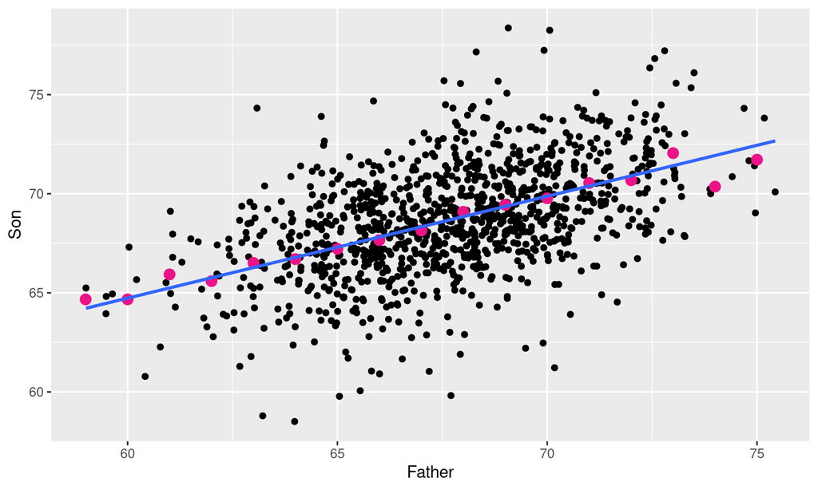

- Average heights for groups with fitted line

## Pearson-Lee height data

The average height of a group of sons depends *linearly* on the father’s given height.

- \[\text{Average height of sons} = 33.89 + .514 \times \text{Father's height} \, ,\]
- \[\text{i.e.}, \quad \quad E( y \mid x ) ~ = ~ 33.89 + .514 \, x \ .\]
- This is *simple linear regression*, handled by `lm` in R :

## Pearson-Lee height data

```r
heights.fit <- lm( Son ~ Father, data = heights)
summary( heights.fit )
```

```
##
## Call:
## lm(formula = Son ~ Father, data = heights)
##
## Residuals:
##     Min      1Q  Median      3Q     Max
## -8.8772 -1.5144 -0.0079  1.6285  8.9685
##
## Coefficients:
##             Estimate Std. Error t value Pr(>|t|)
## (Intercept) 33.88660    1.83235   18.49   <2e-16 ***
## Father       0.51409    0.02705   19.01   <2e-16 ***
## ---
## Signif. codes:  0 '***' 0.001 '**' 0.01 '*' 0.05 '.' 0.1 ' ' 1
##
## Residual standard error: 2.437 on 1076 degrees of freedom
## Multiple R-squared:  0.2513, Adjusted R-squared:  0.2506
## F-statistic: 361.2 on 1 and 1076 DF,  p-value: < 2.2e-16
```

## Pearson-Lee height data

This dataset illustrates regression nicely, but things are actually *too nice* in this example!

- Both variables are roughly normally distributed, neither of which is necessary.
- Many interesting datasets are too small to compute group means and observe the linear relationship directly.

## UNICEF data

The United Nations Children’s Fund (UNICEF) provides [economic and social statistics for countries and territories](http://data.un.org/Explorer.aspx), such as

- Adolescent birth rates
- Literacy rates
- Government expenditures on health and education
- Infant mortality rates
- Life expectancies

## UNICEF data

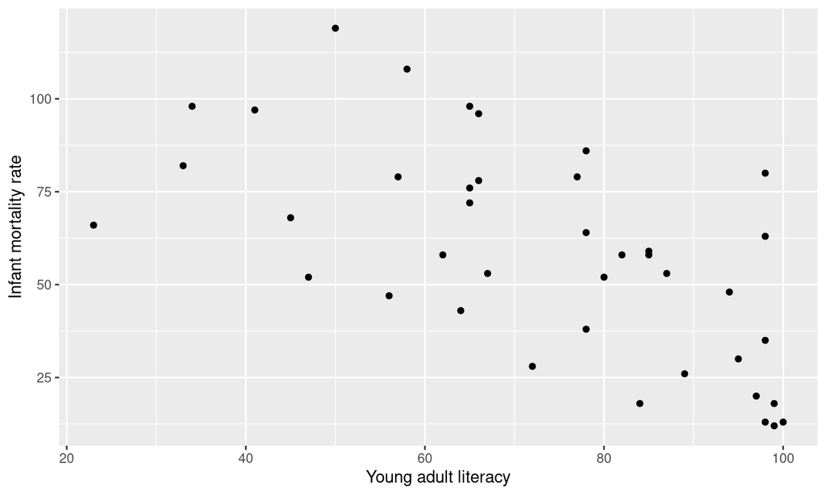

- 40 African countries
- Correlation: -0.6268

## UNICEF data

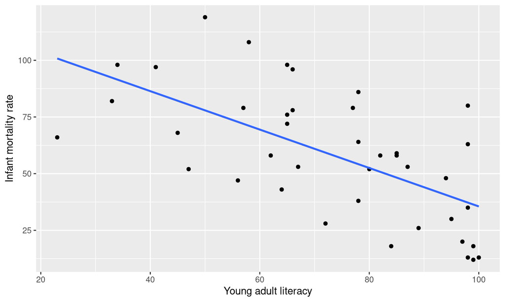

\[\text{Average mortality rate} ~ = ~ 120.29 - .85 \times \text{Literacy}\]

## UNICEF data

```r
unicef.fit <- lm( Deaths ~ LitPercent, data = unicef )
summary( unicef.fit )
```

```
##
## Call:
## lm(formula = Deaths ~ LitPercent, data = unicef)
##
## Residuals:
##    Min     1Q Median     3Q    Max
## -34.80 -18.50   2.98  10.96  42.77
##
## Coefficients:
##             Estimate Std. Error t value Pr(>|t|)
## (Intercept) 120.2917    12.9478   9.291 2.53e-11 ***
## LitPercent   -0.8476     0.1709  -4.959 1.51e-05 ***
## ---
## Signif. codes:  0 '***' 0.001 '**' 0.01 '*' 0.05 '.' 0.1 ' ' 1
##
## Residual standard error: 22.35 on 38 degrees of freedom
## Multiple R-squared:  0.3929, Adjusted R-squared:  0.3769
## F-statistic: 24.59 on 1 and 38 DF,  p-value: 1.51e-05
```

- This model is more *descriptive* than predictive; it is *not* causal!

## College enrollment

All businesses have to anticipate demand – colleges have to predict enrollment.

- A simple idea: use birth statistics, since students were born about 20 years before they enroll.
- The [National Center for Health Statistics](https://www.cdc.gov/nchs/data-visualization/natality-trends/) provides birth data.
- The [National Center for Education Statistics](https://nces.ed.gov/programs/digest/current_tables.asp) provides enrollment data.

## College enrollment

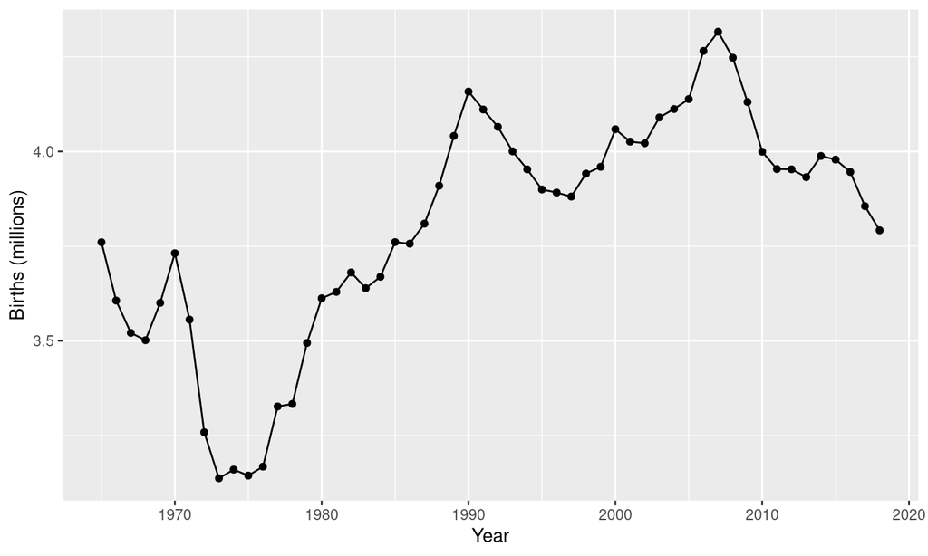

- U.S. births per year, 1965 to 2018

## College enrollment

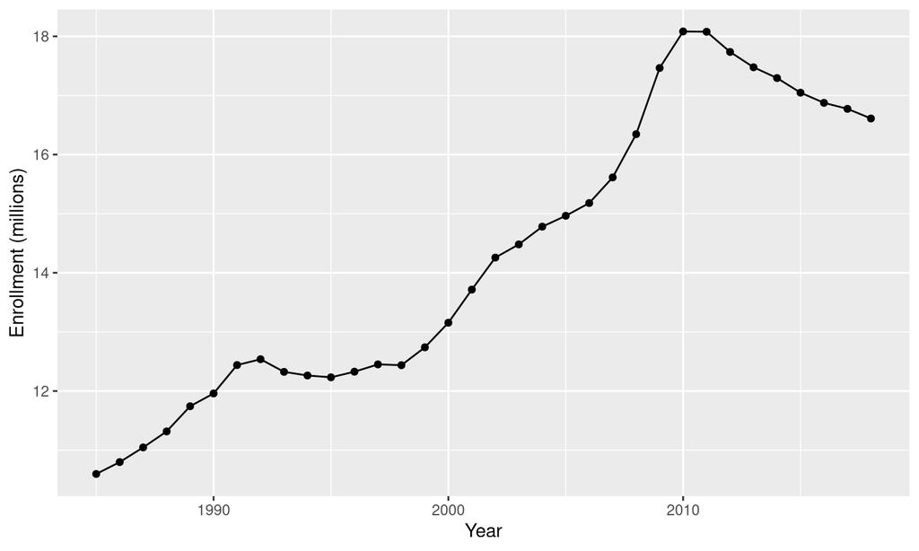

- Full-time U.S. undergraduate enrollments, 1985 to 2018

## College enrollment

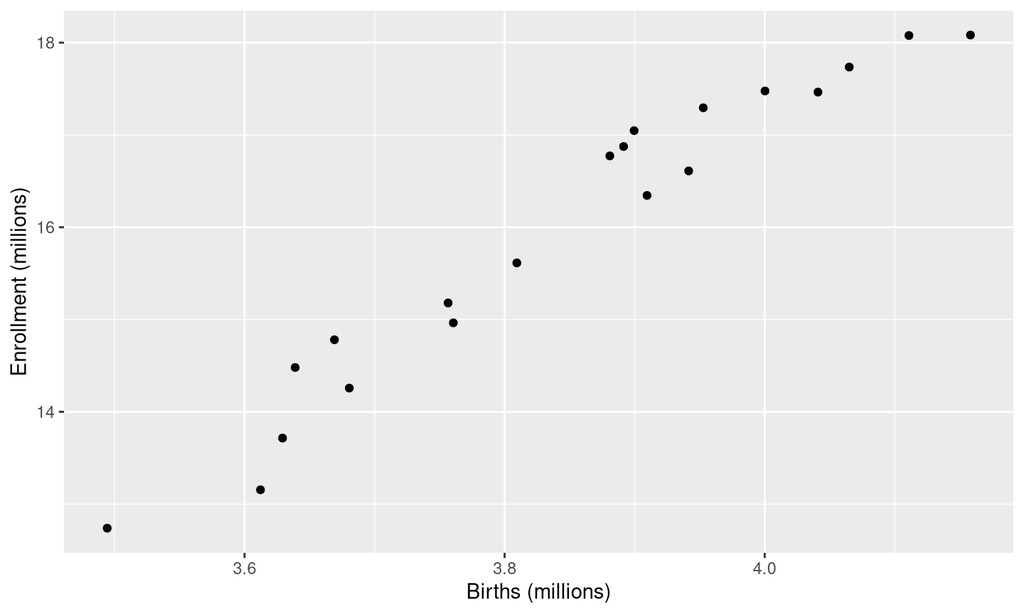

- Correlation: 0.974 (!)

## College enrollment

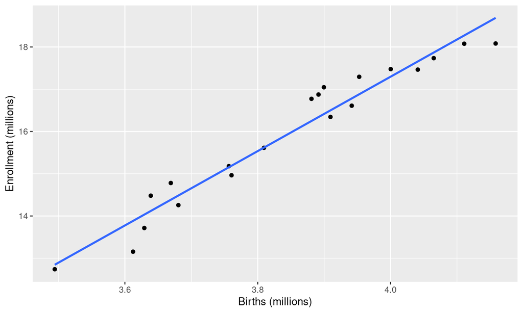

\[\text{Predicted enrollment} ~ = ~ 8.8 \times \text{Births} - 17.9\]

## College enrollment

```r
enroll.fit <- lm( Enrollment ~ Births, data = train)
summary(enroll.fit)
```

```
##
## Call:
## lm(formula = Enrollment ~ Births, data = train)
##
## Residuals:
##     Min      1Q  Median      3Q     Max
## -0.7283 -0.2029 -0.1200  0.3705  0.6339
##
## Coefficients:
##             Estimate Std. Error t value Pr(>|t|)
## (Intercept) -17.9122     1.8513  -9.675 1.48e-08 ***
## Births        8.8022     0.4809  18.302 4.43e-13 ***
## ---
## Signif. codes:  0 '***' 0.001 '**' 0.01 '*' 0.05 '.' 0.1 ' ' 1
##
## Residual standard error: 0.3882 on 18 degrees of freedom
## Multiple R-squared:  0.949,  Adjusted R-squared:  0.9462
## F-statistic:   335 on 1 and 18 DF,  p-value: 4.43e-13
```

## College enrollment

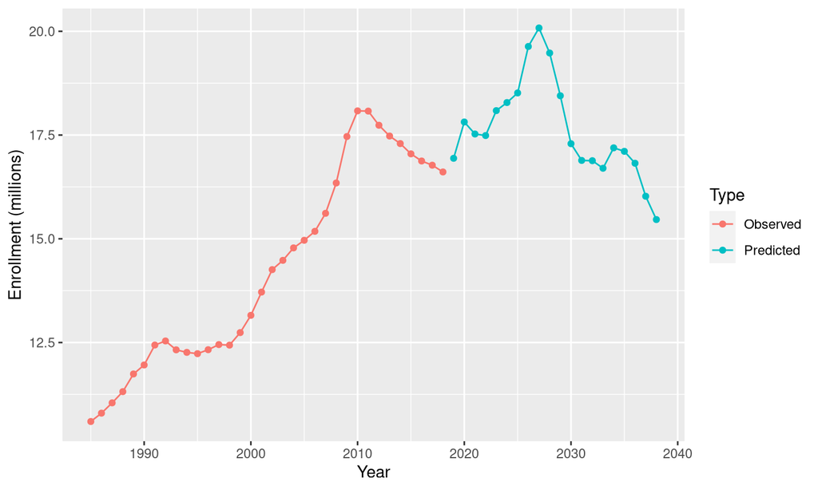

- Higher education is getting even more competitive!

## The simple linear regression model

We use this model when we *believe* that \[y ~ = ~ \beta_{0} + \beta_{1} x + \epsilon \ . \]

- **Main assumptions**: the random error \(~ \epsilon ~\) has *constant variance* and *mean zero* and is uncorrelated across observations.
- **Consequences**: \[ E(y \mid x) ~ = ~ \beta_{0} + \beta_{1}x \quad , \quad \operatorname{Var}(y \mid x) ~ = ~ \sigma^2\]
- **Another assumption**: values of the predictor are known *exactly*.

## The simple linear regression model

- This model makes sense if the mean is a reasonable summary of \(y\). Not true for categorical responses!
- Neither the parameters nor the error can ever be known; they can only be estimated from observations.
- *Nothing is assumed to be normally distributed…*
- yet inferences and model assessment are still possible!

## Ordinary least squares

This is the standard method for estimating \(\, \beta_{0} \,\) and \(\, \beta_{1} \,\).

- Candidate predictive model: \(\quad \hat{y} ~ = ~ a + bx\)
- Minimize the sum of squared residuals, \[\text{RSS} ~ = ~ \sum{ \left( y - \hat{y} \right)^2 } ~ = ~ \sum{ \left( y - a - bx \right)^2 }\]
- Calculus: \[\frac{\partial}{\partial a} \left( \text{RSS} \right) ~ = ~ 0 \quad \Longrightarrow \quad \hat{\beta}_{0} ~ = ~ \bar{y} - \hat{\beta}_{1} \, \bar{x}\] \[\frac{\partial}{\partial b} \left( \text{RSS} \right) ~ = ~ 0 \quad \Longrightarrow \quad \hat{\beta}_{1} ~ = ~ r \left( \frac{ s_{y} }{ s_{x} } \right)\]

## The Gauss-Markov theorem

OLS is BLUE :

- These formulas are the *B*est *L*inear *U*nbiased *E*stimates: \[E( \hat{\beta}_{0} ) = \beta_{0} \ , \quad E( \hat{\beta}_{1} ) = \beta_{1} \ , \quad \text{minimal variance} \ .\]
- Only the previous assumptions are needed; no normality!
- The proof relies on knowing the predictor’s values exactly.

## The Gauss-Markov theorem

The *residual standard error*, \[\text{RSE} ~ = ~ \sqrt{ \frac{ \text{RSS} }{ \ n-2 \ }} ~ = ~ \sqrt{ \frac{ \ \sum{ \left( y - \hat{y} \right)^2 } \ }{ n-2 }} \quad , \] is an unbiased estimate of \(~ \sigma ~ = ~ \operatorname{SD}( \epsilon ) \,\).

## Chebyshev’s inequality

- If \(~ Y ~\) is a random variable with mean \(~ \mu ~\) and SD \(~ \sigma ~\), then \[ \operatorname{Pr}\left\{ \ | Y - \mu | > k \sigma \ \right\} ~ \leq ~ \frac{1}{k^2} \ .\]
- True regardless of distribution!
- If the regression model is correct, then at least 75% of responses will be within about 2 RSEs of the regression line.

## The coefficient of determination

This descriptive statistic compares the regression model and the null model.

- \(\text{OLS} \ \Longrightarrow \ \sum{ \left( y - \bar{y} \right)^2 } ~ = ~ \sum{ \left( y - \hat{y} \right)^2 } + \sum{ \left( \hat{y} - \bar{y} \right)^2 } \ .\)
- Using the predictor reduces variability: \[\sum{ \left( \hat{y} - \bar{y} \right)^2 } ~ = ~ \sum{ \left( y - \bar{y} \right)^2 } - \sum{ \left( y - \hat{y} \right)^2 }\]
- Percentage reduction: \[R^2 ~ = ~ \frac{ \sum{ \left( \hat{y} - \bar{y} \right)^2 } }{ \ \sum{ \left( y - \bar{y} \right)^2 } \ } ~ = ~ 1 ~ - ~ \frac{ \sum{ \left( y - \hat{y} \right)^2 } }{ \ \sum{ \left( y - \bar{y} \right)^2 } \ } \ .\]

## The coefficient of determination

\(R^2\) is the *relative* reduction in variability from using the predictor instead of ignoring it. **That’s all it is!**

- Beware: A correct model can have a low \(R^2\) ; an irrelevant model can have a large \(R^2\).
- It does *not* “explain the variation” in \(\, y \,\)!
- It can only increase when adding predictors – adjusting \(R^2\) doesn’t really help.
- Use with care – and look at your data!

## The normal regression model

What happens if \(~ \epsilon ~ \sim ~ N(0, \sigma^2) \,\) ?

- \(y ~ \sim ~ N(\beta_{0} + \beta_{1}x, \sigma^2)\)
- Regression coefficients have normal sampling distributions, so
- their *studentized statistics* are \(\, t\)-distributed : for the slope, \[\frac{ \, \hat{\beta}_{1} - \beta_{1} \, }{ \text{SE}({\hat{\beta}_{1}}) } ~ \sim ~ t(n-2) \, ,\] \[\text{where} \quad \text{SE}({\hat{\beta}_{1}}) ~ = ~ \frac{\text{RSE}}{\sqrt{ \, \sum{(x - \bar{x})^2} \, } } \ .\]

## The normal regression model

The table summarizing `lm` is based on this normal assumption:

```
##
## Call:
## lm(formula = Enrollment ~ Births, data = train)
##
## Residuals:
##     Min      1Q  Median      3Q     Max
## -0.7283 -0.2029 -0.1200  0.3705  0.6339
##
## Coefficients:
##             Estimate Std. Error t value Pr(>|t|)
## (Intercept) -17.9122     1.8513  -9.675 1.48e-08 ***
## Births        8.8022     0.4809  18.302 4.43e-13 ***
## ---
## Signif. codes:  0 '***' 0.001 '**' 0.01 '*' 0.05 '.' 0.1 ' ' 1
##
## Residual standard error: 0.3882 on 18 degrees of freedom
## Multiple R-squared:  0.949,  Adjusted R-squared:  0.9462
## F-statistic:   335 on 1 and 18 DF,  p-value: 4.43e-13
```

## The normal regression model

This facilitates traditional procedures. For the slope, for example:

- test \(~ H_{0} \, : \, \beta_{1} = 0 ~\) with \(~ t = \frac{ \hat{\beta}_{1} }{ \text{SE}({\hat{\beta}_{1}}) } ~\) ; learn what \(\, p\)-values mean!
- use \(~ \hat{\beta}_{1} ~\) and \(~ \text{SE}({\hat{\beta}_{1}}) ~\) to compute interval estimates of \(~ \beta_{1} ~\) : \[\hat{\beta}_{1} - t^{*} \, \text{SE}({\hat{\beta}_{1}}) ~ \leq ~ \beta_{1} ~ \leq \hat{\beta}_{1} + t^{*} \, \text{SE}({\hat{\beta}_{1}})\]

## The normal regression model

Coefficient estimates in R :

```r
confint(enroll.fit)
```

```
##                  2.5 %     97.5 %
## (Intercept) -21.801601 -14.022703
## Births        7.791778   9.812616
```

- Without assuming normality, use the bootstrap to approximate SEs and obtain interval estimates.
- When adding predictors, everything gets even more complicated!